# **אוכלוסיית הרכבים החשמליים וההיברידיים בוושינגטון**

# מספר קבוצה: 14

### [קישור למאגר הנתונים](https://www.kaggle.com/datasets/ricardobj/electric-vehicle-population)

# **תרומתם של חברי הצוות לפרויקט:**

### הפרויקט היה מאמץ קבוצתי, כאשר כל חבר צוות התרכז בחוזקות שלו תוך תרומה לכל היבטי העבודה.

### נדב היה אחראי על איסוף נתונים, ניקוי הנתונים וניתוח ראשוני.

### דוד התמקד בניתוח סטטיסטי וביצירת ויזואליזציות

### הצוות חילק את המשימות בצורה יעילה, מה שהבטיח את הצלחת הפרויקט בזכות שיתוף פעולה ומסירות.

## **תיאור הפרויקט:**

### הפרויקט מתמקד בניתוח נתונים על רכבים חשמליים (BEVs) והיברידיים (PHEVs) הרשומים בארה"ב, במדינת וושינגטון. הוא כולל נתונים כמו יצרן, דגם, שנת ייצור, טווח נסיעה חשמלי ועוד. המאגר מאפשר מעקב אחר התפתחות וקידום הרכבים חשמליים במדינה.

```python
import pandas as pd
import numpy as np
import matplotlib.pyplot as plt
import seaborn as sns
from tabulate import tabulate
from sklearn.preprocessing import LabelEncoder
```

[figure not shown]

## יצירת דטא פריים

```python
url_1 = 'https://raw.githubusercontent.com/knadav123/Electric_Vehicle_Population_Data/main/Electric_Vehicle_Population_Data_part_1.csv'
url_2 = 'https://raw.githubusercontent.com/knadav123/Electric_Vehicle_Population_Data/main/Electric_Vehicle_Population_Data_part_2.csv'
url_3 = 'https://raw.githubusercontent.com/knadav123/Electric_Vehicle_Population_Data/main/Electric_Vehicle_Population_Data_part_3.csv'

ele1 = pd.read_csv(url_1)
ele2 = pd.read_csv(url_2)
ele3 = pd.read_csv(url_3)

car_df = pd.concat([ele1, ele2, ele3], ignore_index=True)
car_df.head()
```

|  | VIN (1-10) | County | City | State | Postal Code | Model Year | Make | Model | Electric Vehicle Type | Clean Alternative Fuel Vehicle (CAFV) Eligibility | Electric Range | Base MSRP | Legislative District | DOL Vehicle ID | Vehicle Location | Electric Utility | 2020 Census Tract |
| --- | --- | --- | --- | --- | --- | --- | --- | --- | --- | --- | --- | --- | --- | --- | --- | --- | --- |
| 0 | 5YJ3E1EBXK | King | Seattle | WA | 98178.0 | 2019 | TESLA | MODEL 3 | Battery Electric Vehicle (BEV) | Clean Alternative Fuel Vehicle Eligible | 220.0 | 0.0 | 37.0 | 477309682 | POINT (-122.23825 47.49461) | CITY OF SEATTLE - (WA)\|CITY OF TACOMA - (WA) | 5.303301e+10 |
| 1 | 5YJYGDEE3L | Kitsap | Poulsbo | WA | 98370.0 | 2020 | TESLA | MODEL Y | Battery Electric Vehicle (BEV) | Clean Alternative Fuel Vehicle Eligible | 291.0 | 0.0 | 23.0 | 109705683 | POINT (-122.64681 47.73689) | PUGET SOUND ENERGY INC | 5.303509e+10 |
| 2 | KM8KRDAF5P | Kitsap | Olalla | WA | 98359.0 | 2023 | HYUNDAI | IONIQ 5 | Battery Electric Vehicle (BEV) | Eligibility unknown as battery range has not b... | 0.0 | 0.0 | 26.0 | 230390492 | POINT (-122.54729 47.42602) | PUGET SOUND ENERGY INC | 5.303509e+10 |
| 3 | 5UXTA6C0XM | Kitsap | Seabeck | WA | 98380.0 | 2021 | BMW | X5 | Plug-in Hybrid Electric Vehicle (PHEV) | Clean Alternative Fuel Vehicle Eligible | 30.0 | 0.0 | 35.0 | 267929112 | POINT (-122.81585 47.64509) | PUGET SOUND ENERGY INC | 5.303509e+10 |
| 4 | JTMAB3FV7P | Thurston | Rainier | WA | 98576.0 | 2023 | TOYOTA | RAV4 PRIME | Plug-in Hybrid Electric Vehicle (PHEV) | Clean Alternative Fuel Vehicle Eligible | 42.0 | 0.0 | 2.0 | 236505139 | POINT (-122.68993 46.88897) | PUGET SOUND ENERGY INC | 5.306701e+10 |

## תיאור קצר של הדטא

```python
print("The rows and columns:", car_df.shape)

rows = len(car_df)
print(f"The number of rows is {rows}")

columns = len(car_df.columns)
print(f"The number of columns is {columns}")

numeric_columns = len(car_df.select_dtypes(include="number").columns)
print(f"The number of numeric columns is {numeric_columns}")

categorical_columns = len(car_df.select_dtypes(include="object").columns)
print(f"The number of categorical columns is {categorical_columns}")
```

```
The rows and columns: (235692, 17)
The number of rows is 235692
The number of columns is 17
The number of numeric columns is 7
The number of categorical columns is 10
```

```python
car_df.describe()
```

|  | Postal Code | Model Year | Electric Range | Base MSRP | Legislative District | DOL Vehicle ID | 2020 Census Tract |
| --- | --- | --- | --- | --- | --- | --- | --- |
| count | 235689.000000 | 235692.000000 | 235656.000000 | 235656.000000 | 235198.000000 | 2.356920e+05 | 2.356890e+05 |
| mean | 98177.656463 | 2021.406658 | 46.262569 | 787.268328 | 28.879519 | 2.353127e+08 | 5.298066e+10 |
| std | 2524.218661 | 2.991908 | 84.045829 | 7177.668305 | 14.904644 | 6.799098e+07 | 1.521066e+09 |
| min | 1731.000000 | 2000.000000 | 0.000000 | 0.000000 | 1.000000 | 4.385000e+03 | 1.001020e+09 |
| 25% | 98052.000000 | 2020.000000 | 0.000000 | 0.000000 | 17.000000 | 2.053457e+08 | 5.303301e+10 |
| 50% | 98126.000000 | 2023.000000 | 0.000000 | 0.000000 | 32.000000 | 2.522795e+08 | 5.303303e+10 |
| 75% | 98374.000000 | 2024.000000 | 38.000000 | 0.000000 | 42.000000 | 2.696401e+08 | 5.305307e+10 |
| max | 99577.000000 | 2025.000000 | 337.000000 | 845000.000000 | 49.000000 | 4.792548e+08 | 5.602100e+10 |

## בדיקת העמודות

```python
car_df.columns
```

```
Index(['VIN (1-10)', 'County', 'City', 'State', 'Postal Code', 'Model Year',
       'Make', 'Model', 'Electric Vehicle Type',
       'Clean Alternative Fuel Vehicle (CAFV) Eligibility', 'Electric Range',
       'Base MSRP', 'Legislative District', 'DOL Vehicle ID',
       'Vehicle Location', 'Electric Utility', '2020 Census Tract'],
      dtype='object')
```

## נבצע סינון של עמודות לא רלוונטיות ונציג את הטבלה

```python
car_df = car_df.drop(columns=["index","VIN (1-10)","State","Postal Code","DOL Vehicle ID","Vehicle Location","Vehicle Locatio", "2020 Census Tract"], errors="ignore")
car_df.head(4)
```

|  | County | City | Model Year | Make | Model | Electric Vehicle Type | Clean Alternative Fuel Vehicle (CAFV) Eligibility | Electric Range | Base MSRP | Legislative District | Electric Utility |
| --- | --- | --- | --- | --- | --- | --- | --- | --- | --- | --- | --- |
| 0 | King | Seattle | 2019 | TESLA | MODEL 3 | Battery Electric Vehicle (BEV) | Clean Alternative Fuel Vehicle Eligible | 220.0 | 0.0 | 37.0 | CITY OF SEATTLE - (WA)\|CITY OF TACOMA - (WA) |
| 1 | Kitsap | Poulsbo | 2020 | TESLA | MODEL Y | Battery Electric Vehicle (BEV) | Clean Alternative Fuel Vehicle Eligible | 291.0 | 0.0 | 23.0 | PUGET SOUND ENERGY INC |
| 2 | Kitsap | Olalla | 2023 | HYUNDAI | IONIQ 5 | Battery Electric Vehicle (BEV) | Eligibility unknown as battery range has not b... | 0.0 | 0.0 | 26.0 | PUGET SOUND ENERGY INC |
| 3 | Kitsap | Seabeck | 2021 | BMW | X5 | Plug-in Hybrid Electric Vehicle (PHEV) | Clean Alternative Fuel Vehicle Eligible | 30.0 | 0.0 | 35.0 | PUGET SOUND ENERGY INC |

## נבדוק האם קיימים נתונים חריגים והאם הם רלוונטיים או לא

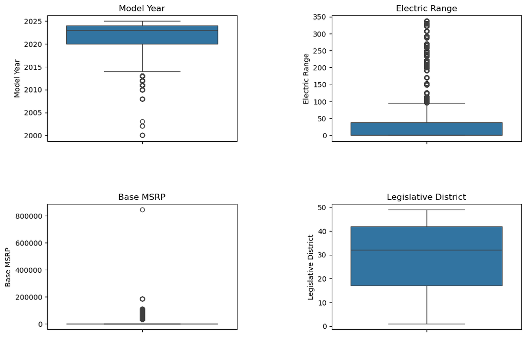

```python
fig, ax = plt.subplots(2, 2, figsize=(12, 8))

plt.subplots_adjust(wspace=0.5, hspace=0.5)

sns.boxplot(y=car_df['Model Year'], ax=ax[0, 0])
ax[0, 0].set_title('Model Year')

sns.boxplot(y=car_df['Electric Range'], ax=ax[0, 1])
ax[0, 1].set_title('Electric Range')

sns.boxplot(y=car_df['Base MSRP'], ax=ax[1, 0])
ax[1, 0].set_title('Base MSRP')

sns.boxplot(y=car_df['Legislative District'], ax=ax[1, 1])
ax[1, 1].set_title('Legislative District')

plt.show()
```

## נבדוק אילו סוגי ערכים יש בעמודות שבהם יש לנו חריגים

```python
unique_values1 = car_df["Electric Range"].unique()
unique_values2 = car_df["Base MSRP"].unique()

print(unique_values1)
print(unique_values2)
```

```
[220. 291.   0.  30.  42. 265.  81.  22. 215.  84. 289.  26. 233. 208.
 114. 210.  75. 107. 238.  32.  25. 293.  53.  39.  82.  33.  28. 170.
  93.  21. 150.  38.  16. 125.  14.  37.  47. 149. 151. 266.  19.  73.
 259.  23.  13. 308.  97. 192. 322. 258. 249.  35.  62.  18. 239.  17.
  83. 200. 234.  40.  34. 222.  72. 100.  68.  87.  20.  54. 126.   6.
  29.  15. 103. 270. 288.  41.  76.  58.  46.  60. 124. 203. 330.  48.
  nan  31. 337. 153. 218.  56. 204.   8. 111.  36.  10. 110.  49.  27.
  59.  24.  43.  12. 245.  11.  55.   9.  95.  57.  51.  45.]
[     0.  59900.  69900.  31950.  44100.  32250.  54950.  45600.  52650.
  55700.  52900.     nan  33950.  64950.  53400.  98950.  34995.  43700.
  39995. 184400.  36800. 110950.  36900.  81100. 102000. 109000.  75095.
  90700.  89100.  91250.  32995. 845000.]
```

## ניתן להסיק כי יש מספר רב של נתונים שהם 0 או ריקים ולכן נגביל את הטווח ונבדוק אם עדיין נראה חריג

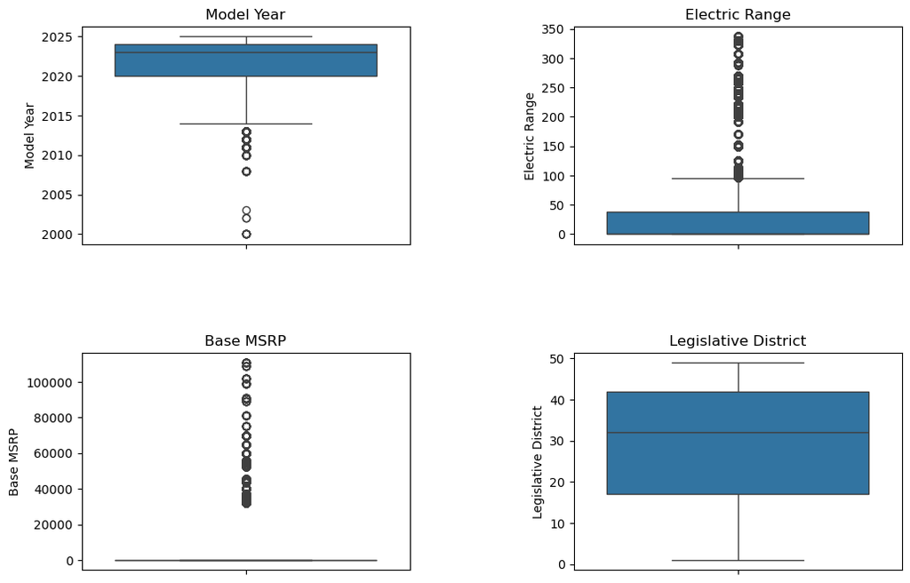

```python
car_df = car_df[car_df["Base MSRP"] <= 150000]
fig, ax = plt.subplots(2, 2, figsize=(12, 8))

plt.subplots_adjust(wspace=0.5, hspace=0.5)

sns.boxplot(y=car_df['Model Year'], ax=ax[0, 0])
ax[0, 0].set_title('Model Year')

sns.boxplot(y=car_df['Electric Range'], ax=ax[0, 1])
ax[0, 1].set_title('Electric Range')

sns.boxplot(y=car_df['Base MSRP'], ax=ax[1, 0])
ax[1, 0].set_title('Base MSRP')

sns.boxplot(y=car_df['Legislative District'], ax=ax[1, 1])
ax[1, 1].set_title('Legislative District')

plt.show()
```

## ניתן לראות שגם לאחר סינון בעמודת עדיין החציון נמצא על אפס כלומר חסרים לנו שם יותר מידי נתונים ולכן נוריד את העמודה Base MSRP מהדטא

```python
car_df = car_df.drop(columns=["Base MSRP"], errors="ignore")
car_df
```

|  | County | City | Model Year | Make | Model | Electric Vehicle Type | Clean Alternative Fuel Vehicle (CAFV) Eligibility | Electric Range | Legislative District | Electric Utility |
| --- | --- | --- | --- | --- | --- | --- | --- | --- | --- | --- |
| 0 | King | Seattle | 2019 | TESLA | MODEL 3 | Battery Electric Vehicle (BEV) | Clean Alternative Fuel Vehicle Eligible | 220.0 | 37.0 | CITY OF SEATTLE - (WA)\|CITY OF TACOMA - (WA) |
| 1 | Kitsap | Poulsbo | 2020 | TESLA | MODEL Y | Battery Electric Vehicle (BEV) | Clean Alternative Fuel Vehicle Eligible | 291.0 | 23.0 | PUGET SOUND ENERGY INC |
| 2 | Kitsap | Olalla | 2023 | HYUNDAI | IONIQ 5 | Battery Electric Vehicle (BEV) | Eligibility unknown as battery range has not b... | 0.0 | 26.0 | PUGET SOUND ENERGY INC |
| 3 | Kitsap | Seabeck | 2021 | BMW | X5 | Plug-in Hybrid Electric Vehicle (PHEV) | Clean Alternative Fuel Vehicle Eligible | 30.0 | 35.0 | PUGET SOUND ENERGY INC |
| 4 | Thurston | Rainier | 2023 | TOYOTA | RAV4 PRIME | Plug-in Hybrid Electric Vehicle (PHEV) | Clean Alternative Fuel Vehicle Eligible | 42.0 | 2.0 | PUGET SOUND ENERGY INC |
| ... | ... | ... | ... | ... | ... | ... | ... | ... | ... | ... |
| 235687 | Pierce | Tacoma | 2024 | JEEP | WRANGLER | Plug-in Hybrid Electric Vehicle (PHEV) | Not eligible due to low battery range | 21.0 | 27.0 | BONNEVILLE POWER ADMINISTRATION\|\|CITY OF TACOM... |
| 235688 | Snohomish | Stanwood | 2018 | TESLA | MODEL S | Battery Electric Vehicle (BEV) | Clean Alternative Fuel Vehicle Eligible | 249.0 | 10.0 | BONNEVILLE POWER ADMINISTRATION\|\|PUD 1 OF SNOH... |
| 235689 | King | Redmond | 2015 | FORD | FUSION | Plug-in Hybrid Electric Vehicle (PHEV) | Not eligible due to low battery range | 19.0 | 48.0 | PUGET SOUND ENERGY INC\|\|CITY OF TACOMA - (WA) |
| 235690 | Snohomish | Lake Stevens | 2023 | AUDI | Q4 | Battery Electric Vehicle (BEV) | Eligibility unknown as battery range has not b... | 0.0 | 44.0 | PUGET SOUND ENERGY INC |
| 235691 | King | Issaquah | 2023 | BMW | I4 | Battery Electric Vehicle (BEV) | Eligibility unknown as battery range has not b... | 0.0 | 5.0 | PUGET SOUND ENERGY INC\|\|CITY OF TACOMA - (WA) |

235645 rows × 10 columns

## **שלוש שאלות ראשוניות שמעניין אותנו להוציא מהקובץ:**

### 1. מהם המותגים הפופולריים ביותר של רכבים חשמליים לפי שנה?

### 2. באילו אזורים יש ריכוז גבוה יותר של רכבים חשמליים?

### 3. כיצד חלוקה לפי מאפיינים (כמו שנות ייצור) משפיעה על זכאות הרכבים לדלק אלטרנטיבי נקי (CAFV)?

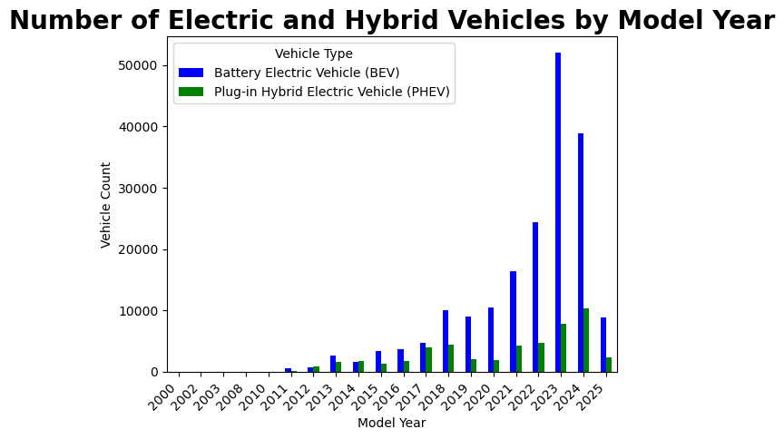

```python
grouped_df = car_df.groupby(["Model Year", "Electric Vehicle Type"]).size().unstack().fillna(0)

plt.figure(figsize=(12, 6))
grouped_df.plot(kind='bar', stacked=False, color=["blue", "green"])

plt.xticks(rotation=45, ha="right")
plt.title("Number of Electric and Hybrid Vehicles by Model Year", fontsize=20, fontweight='bold')
plt.xlabel("Model Year")
plt.ylabel("Vehicle Count")
plt.legend(title="Vehicle Type")
plt.show()
```

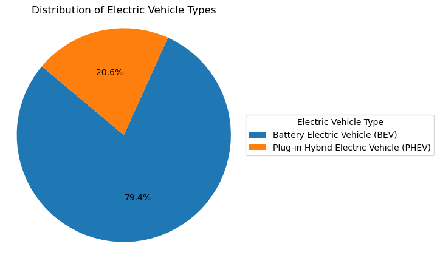

```python
vehicle_type_counts = car_df["Electric Vehicle Type"].value_counts()

colors = plt.colormaps["tab10"](range(len(vehicle_type_counts)))
plt.figure(figsize=(5, 5))
plt.pie(vehicle_type_counts, labels=[""] * len(vehicle_type_counts), autopct='%1.1f%%',
        colors=colors, startangle=140)
plt.legend(vehicle_type_counts.index, title="Electric Vehicle Type", loc="center left", bbox_to_anchor=(1, 0.5))
plt.title("Distribution of Electric Vehicle Types")
plt.axis("equal")
plt.show()
```

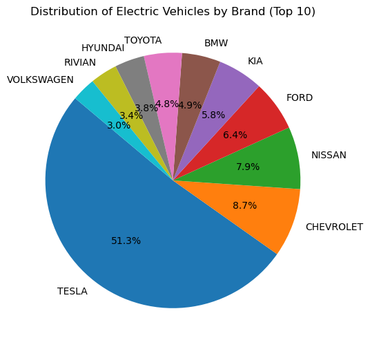

```python
brand_counts = car_df['Make'].value_counts()

plt.figure(figsize=(10, 6))
brand_counts[:10].plot(kind='pie', autopct='%1.1f%%', startangle=140, colormap='tab10')
plt.title("Distribution of Electric Vehicles by Brand (Top 10)")
plt.ylabel("")  # הסרת כותרת ציר Y
plt.show()
```

```python
ezer_df = car_df[pd.to_numeric(car_df['Model Year'], errors='coerce').notna()]
ezer_df['Model Year'] = ezer_df['Model Year'].astype(int)


ev_df = ezer_df[ezer_df["Electric Vehicle Type"] == "Battery Electric Vehicle (BEV)"]
hybrid_df = ezer_df[ezer_df["Electric Vehicle Type"] == "Plug-in Hybrid Electric Vehicle (PHEV)"]


popular_ev_make = ev_df.groupby("Model Year")["Make"].agg(lambda x: x.value_counts().idxmax()).reset_index()
popular_ev_make.columns = ["Model Year", "Most Popular Full Electric Brand"]

popular_hybrid_make = hybrid_df.groupby("Model Year")["Make"].agg(lambda x: x.value_counts().idxmax()).reset_index()
popular_hybrid_make.columns = ["Model Year", "Most Popular Hybrid Brand"]

popular_vehicles_by_year = pd.merge(popular_ev_make, popular_hybrid_make, on="Model Year", how="outer")


popular_vehicles_by_year
```

|  | Model Year | Most Popular Full Electric Brand | Most Popular Hybrid Brand |
| --- | --- | --- | --- |
| 0 | 2000 | FORD | NaN |
| 1 | 2002 | TOYOTA | NaN |
| 2 | 2003 | TOYOTA | NaN |
| 3 | 2008 | TESLA | NaN |
| 4 | 2010 | TESLA | WHEEGO ELECTRIC CARS |
| 5 | 2011 | NISSAN | CHEVROLET |
| 6 | 2012 | NISSAN | CHEVROLET |
| 7 | 2013 | NISSAN | CHEVROLET |
| 8 | 2014 | TESLA | CHEVROLET |
| 9 | 2015 | NISSAN | FORD |
| 10 | 2016 | TESLA | FORD |
| 11 | 2017 | TESLA | CHEVROLET |
| 12 | 2018 | TESLA | CHEVROLET |
| 13 | 2019 | TESLA | BMW |
| 14 | 2020 | TESLA | TOYOTA |
| 15 | 2021 | TESLA | TOYOTA |
| 16 | 2022 | TESLA | JEEP |
| 17 | 2023 | TESLA | JEEP |
| 18 | 2024 | TESLA | JEEP |
| 19 | 2025 | TESLA | BMW |

## **מסקנה ראשונה:**

### על פי הטבלה כבר בשנת 2008 הפכה טסלה לחברה מובילה בתחום הרכבים החשמליים בארצות הברית בעוד בישראל היא הגיעה לארץ לראשונה רק בשנת 2021. ההבנה איזה מותג הוא הדומיננטי חשובה על מנת לדעת איזה סוג מטענים לפתח ולהציב ברחבי האיזור שכן לחברות רבות יש שקעים שונים לרכבים שלהם.

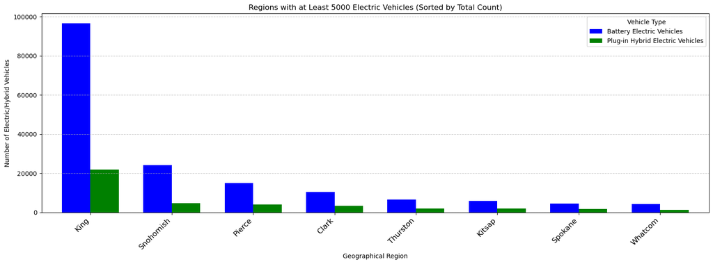

```python
ezer_df = car_df.copy()
ezer_df.columns = ezer_df.columns.str.strip().str.lower()

geo_column = next((col for col in ezer_df.columns if 'state' in col or 'county' in col or 'region' in col), None)

if geo_column:
    ev_df = ezer_df[ezer_df["electric vehicle type"] == "Battery Electric Vehicle (BEV)"]
    hybrid_df = ezer_df[ezer_df["electric vehicle type"] == "Plug-in Hybrid Electric Vehicle (PHEV)"]

    ev_distribution = ev_df.groupby(geo_column).size().reset_index(name="Number of BEVs")
    hybrid_distribution = hybrid_df.groupby(geo_column).size().reset_index(name="Number of PHEVs")

    geo_distribution = pd.merge(ev_distribution, hybrid_distribution, on=geo_column, how="outer").fillna(0)

    geo_distribution["Total Vehicles"] = geo_distribution["Number of BEVs"] + geo_distribution["Number of PHEVs"]

    geo_distribution = geo_distribution[geo_distribution["Total Vehicles"] >= 5000]

    geo_distribution = geo_distribution.sort_values(by="Total Vehicles", ascending=False)

    geo_distribution.set_index(geo_column)[["Number of BEVs", "Number of PHEVs"]].plot(
        kind='bar', stacked=False, figsize=(16, 6), width=0.7, color=["blue", "green"]
    )

    plt.xlabel('Geographical Region')
    plt.ylabel('Number of Electric/Hybrid Vehicles')
    plt.title('Regions with at Least 5000 Electric Vehicles (Sorted by Total Count)')
    plt.xticks(rotation=45, ha='right', fontsize=12)
    plt.legend(title="Vehicle Type", labels=["Battery Electric Vehicles", "Plug-in Hybrid Electric Vehicles"])
    plt.grid(axis='y', linestyle='--', alpha=0.7)
    plt.tight_layout()
    plt.show()
else:
    print("No column describing geographical regions was found. Check available column names:", ezer_df.columns.tolist())
```

## **מסקנה שנייה:**

### ניתן לראות לפי הגרף כי במחוז קינג יש את המספר הרב ביותר של רכבים חשמליים, נתון זה חשוב על מנת לדעת איפה צריך להשקיע את המשאבים הנדרשים לרכבים חשמליים.

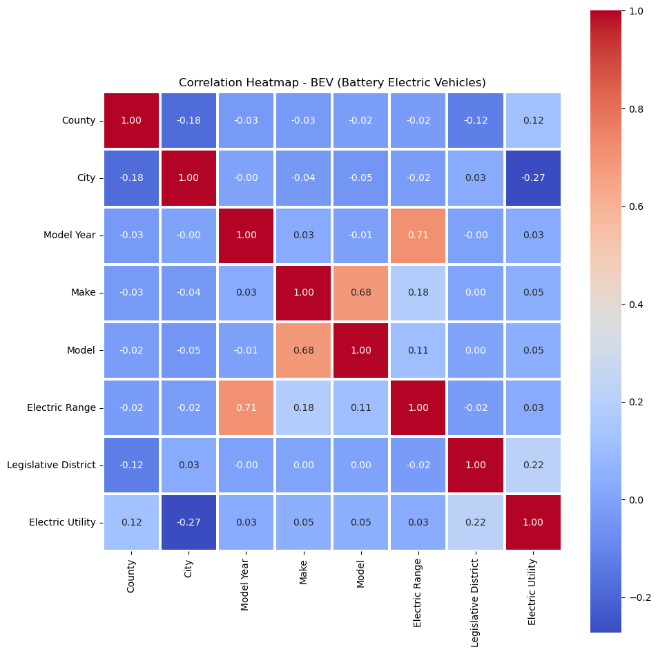

```python
bev_df = car_df[car_df["Electric Vehicle Type"] == "Battery Electric Vehicle (BEV)"].copy()

bev_df = bev_df[bev_df["Electric Range"] != 0]

bev_df = bev_df.drop(columns=["Electric Vehicle Type", "Clean Alternative Fuel Vehicle (CAFV) Eligibility"], errors="ignore")

bev_df = bev_df.apply(lambda col: LabelEncoder().fit_transform(col) if col.dtype == "object" else col)

corr_bev = bev_df.corr()

plt.figure(figsize=(10, 10))
sns.heatmap(corr_bev, annot=True, cmap="coolwarm", fmt=".2f", linewidths=1.5, square=True, annot_kws={"size": 10})
plt.title("Correlation Heatmap - BEV (Battery Electric Vehicles)")
plt.tight_layout()
plt.show()
```

## **מתוך הקורלציה יש לנו קשר בולט:**

### קיים קשר חזק של 0.71 בין טווח הנסיעה החשמלי של הרכב לבין שנת הייצור שלו.

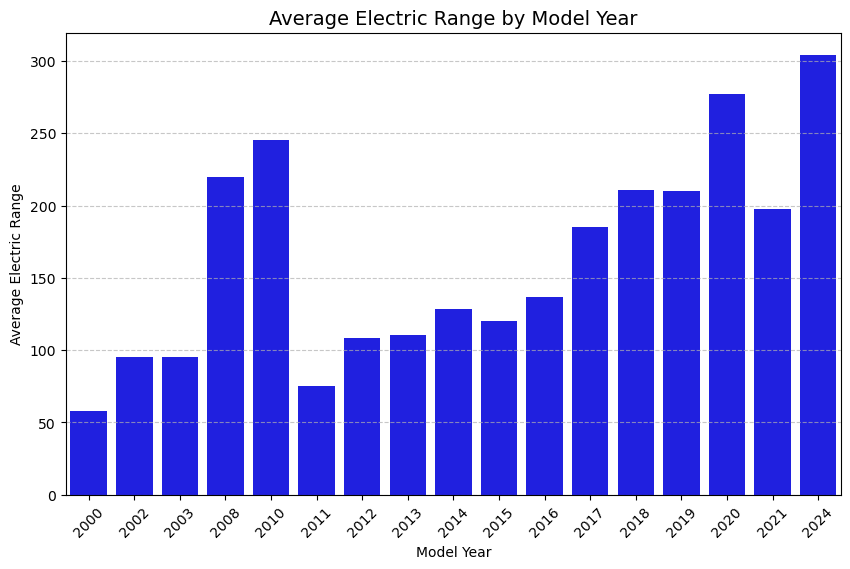

```python
avg_range_by_year = bev_df.groupby("Model Year")["Electric Range"].mean().reset_index()

plt.figure(figsize=(10, 6))
sns.barplot(data=avg_range_by_year, x="Model Year", y="Electric Range", color="blue")

plt.title("Average Electric Range by Model Year", fontsize=14)
plt.xlabel("Model Year")
plt.ylabel("Average Electric Range")
plt.xticks(rotation=45)
plt.grid(axis="y", linestyle="--", alpha=0.7)

plt.show()
```

## הגרף מציג את הממוצע של טווח הנסיעה החשמלי בכל שנה, לפי הגרף ניתן להסיק שכפי שהיה מצופה אכן טווח הנסיעה החשמלי גדל עם השנים.

[figure not shown]

```python
phev_df = car_df[car_df["Electric Vehicle Type"] == "Plug-in Hybrid Electric Vehicle (PHEV)"].copy()

phev_df = phev_df[phev_df["Electric Range"] != 0]

phev_df = phev_df.drop(columns=["Electric Vehicle Type"], errors="ignore")

phev_df = phev_df.apply(lambda col: LabelEncoder().fit_transform(col) if col.dtype == "object" else col)

corr_bev = phev_df.corr()

plt.figure(figsize=(10, 10))
sns.heatmap(corr_bev, annot=True, cmap="coolwarm", fmt=".2f", linewidths=1.5, square=True, annot_kws={"size": 10})
plt.title("Correlation Heatmap - BEV (Battery Electric Vehicles)")
plt.tight_layout()
plt.show()
```

### 2. קיימת קורולציה חלשה של 0.137 בין תקן CAFV לבין היצרן, מה שמצביע כי אולי יש יצרניות שהתקן כן מעניין אותן.

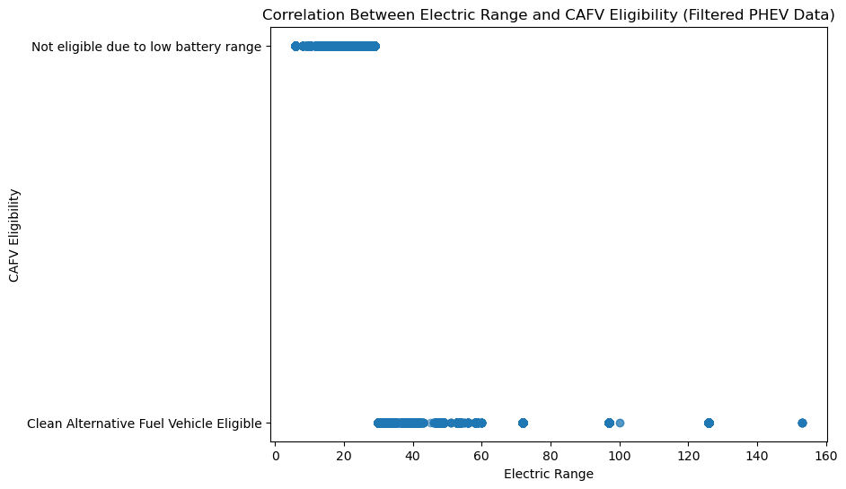

```python
phev_df = car_df[(car_df["Electric Vehicle Type"] == "Plug-in Hybrid Electric Vehicle (PHEV)") & (car_df["Electric Range"] > 0)].copy()

plt.figure(figsize=(8, 6))
plt.scatter(phev_df["Electric Range"], phev_df["Clean Alternative Fuel Vehicle (CAFV) Eligibility"], alpha=0.5)

plt.xlabel("Electric Range")
plt.ylabel("CAFV Eligibility")
plt.title("Correlation Between Electric Range and CAFV Eligibility (Filtered PHEV Data)")

plt.show()
```

## **מסקנה שלישית:**

### ניתן לראות כי קיימת סתירה לקורולציה שקיבלנו וכמו שחשבנו בהתחלה ככול שהטווח החשמלי גבוהה יותר כך קיים סיכוי גבוה יותר לקבל את התקן.

[figure not shown]

```python
phev_df = car_df[car_df["Electric Vehicle Type"] == "Plug-in Hybrid Electric Vehicle (PHEV)"].copy()

label_encoder = LabelEncoder()
phev_df["CAFV Eligibility Encoded"] = label_encoder.fit_transform(phev_df["Clean Alternative Fuel Vehicle (CAFV) Eligibility"])

make_cafv_counts = phev_df.groupby("Make")["CAFV Eligibility Encoded"].sum()
make_total_counts = phev_df.groupby("Make")["CAFV Eligibility Encoded"].count()
make_avg_cafv = (make_cafv_counts / make_total_counts) * 100  # אחוזים מתוך 100

make_avg_cafv_df = make_avg_cafv.reset_index()
make_avg_cafv_df.columns = ["Make", "CAFV Eligibility Percentage"]

plt.figure(figsize=(12, 6))
plt.bar(make_avg_cafv_df["Make"], make_avg_cafv_df["CAFV Eligibility Percentage"])

for i, v in enumerate(make_avg_cafv_df["CAFV Eligibility Percentage"]):
    plt.text(i, v + 1, f"{v:.1f}%", ha="center", fontsize=10)

plt.xticks(rotation=90)
plt.xlabel("Make")
plt.ylabel("CAFV Eligibility (%)")
plt.title("CAFV Eligibility by Vehicle Make (Percentage)")

plt.show()
```

## **מסקנה חמשית ומפתיעה:**

### לפי הגרף וטבלת הרכבים הפופולריים ביותר בכל שנה גילינו שהתקן לא בהכרח משפיע על ההחלטה של הלקוחות איזה רכב לקנות ושל איזה חברה.

# **סיכום:**

## הפרויקט התמקד בניתוח נתונים על רכבים חשמליים במדינת וושינגטון, תוך יישום שיטות ניתוח מתקדמות שהובילו לתובנות משמעותיות. במהלך העבודה בחנו את מגמות הצמיחה של רכבים חשמליים לאורך השנים, זיהינו את היצרנים והדגמים הפופולריים ביותר. הפרויקט דרש השקעה רבה, החל מניקוי ועיבוד הנתונים, דרך ביצוע ניתוחים מקיפים ועד להצגת הממצאים. התמודדנו עם אתגרים כמו עומס עבודה במהלך הסמסטר , אך פעלנו יחד כצוות כדי לעמוד בלוחות הזמנים ולמקסם את תובנות המחקר. פרויקט זה חיזק את היכולות שלנו בעבודה עם נתונים אמיתיים, ביצוע ניתוחים מתקדמים ושיתוף פעולה אפקטיבי בצוות. אנו גאים בתוצאות שהשגנו ובהשפעת המחקר על הבנת מגמות הרכבים החשמליים.

## **מקורות:**

### https://catalog.data.gov/dataset/electric-vehicle-population-data